# Zone Exit Value Above Expected

Alex Novet

November 4, 2017

For this data sprint, I intend to focus my efforts on zone exits. What makes a good or bad zone exit? What should our expectations be given the circumstances? Which teams and players are the best at zone exits?

## Part 1: Data Exploration and Zone Exit Success

I think zone exits should be evaluated based on what happens later in the play. Traditionally, zone exits are considered a “success” if the puck leaves the defensive zone. However, there’s little value in a zone exit that just tosses the puck back to the opponent in the neutral zone. Rather, a truly successful zone exit gives its team the next zone entry. So, I want to look at every zone exit and define success based on who gets the next zone entry.

```r
#Find the transition event after each zone exit (imperfect, but acceptable for now)
exit_entry <- filter(dat1, game_state == "5v5",
                     type %in% c("zone_exit", "zone_entry"),
                     !sub_type %in% c("failed", "icing", "dump_change")) %>%
  group_by(game_id, period) %>%
  mutate(next_transition_team = lead(team_id))

#Define success for each exit based on the next transition play
exits1 <- exit_entry %>%
  filter(type == "zone_exit") %>%
  mutate(successful_exit = team_id == next_transition_team)

#Now merge this information back into the original data file, and make it 5v5
dat2 <- dat1 %>%
  filter(game_state == "5v5") %>%
  left_join(exits1)
```

With success defined, we can do a quick check of success by exit type. I did this at RITHAC this year for the NHL, but it’s good to check again with this data

```r
exits2 <- dat2 %>%
  filter(type == "zone_exit") %>% #Remove the ones at the end of the period with no subsequent event
  mutate(successful_exit = ifelse(sub_type %in% c("failed", "icing", "dump_change"), FALSE, successful_exit)) %>%
  filter(!is.na(successful_exit))

exit_success_QC <- group_by(exits2, sub_type) %>%
  summarise(n = n(), successes = sum(successful_exit)) %>%
  mutate(rate = successes/n)

exit_success_QC
```

```
## # A tibble: 6 x 4
##      sub_type     n successes      rate
##        <fctr> <int>     <int>     <dbl>
## 1        chip 10920      5310 0.4862637
## 2 dump_change   144         0 0.0000000
## 3      failed  1380         0 0.0000000
## 4       icing   924         0 0.0000000
## 5        pass  8846      7464 0.8437712
## 6       skate  9111      7784 0.8543519
```

Unsurprisingly, success by type mirrors the NHL: passing and skating are almost equivalently successful, while dumping the puck out is far less successful. It seems all types have higher success rates than in the NHL (looser defensive structures?), but that could easily be a data collection difference between Corey and this dataset.

Now that we have success defined, we can see how location in the zone affects the success rate. This is the first time such data has been available publicly, so it will be very interesting to see how the location of the puck at the time the zone exit starts affects the success (and the type of attempt used).

Methodology notes: I’m taking the negative absolute value of the x-value so that exits from either end of the ice are counted equivalently and the plot has the net on the far left. I’m also cutting the values off and removing anything with x < 25, as that’s my best evaluation for where the blue line is.

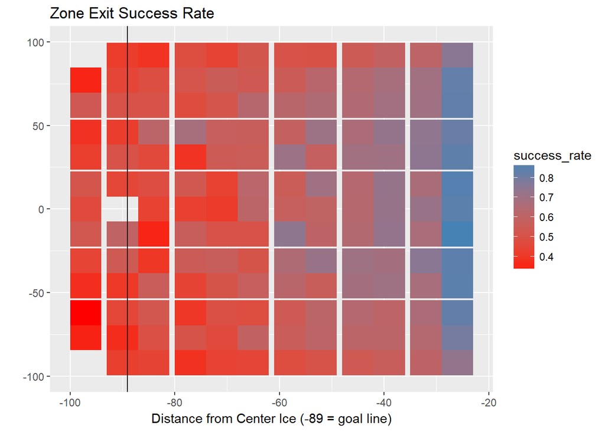

```r
exit_success <- exits2 %>%
  mutate(main_x = -abs(main_x)) %>%
  group_by(main_x, main_y) %>%
  summarise(n = n(), successes = sum(successful_exit)) %>%
  mutate(success_rate = successes/n) %>%
  filter(main_x < -25,
         main_x > -92 | abs(main_y) < 92,
         n > 10) #Removing neutral zone, non-existant corners, and inside the net

#Plot this data
ggplot(exit_success, aes(x = main_x, y = main_y)) +
  geom_tile(aes(fill = success_rate)) +
  scale_fill_gradient(low = "red", high = "steelblue") +
  xlab("Distance from Center Ice (-89 = goal line)") +
  ylab("") +
  ggtitle("Zone Exit Success Rate") +
  geom_vline(xintercept=-89) #Add goal line
```

From this, we can see that exits that start closer to the neutral zone are more likely to succeed, as are exits closer to the center of the ice. Exits starting at the boards, especially in the corners, have a lower success rate.

We can also see the frequency of zone exits by location:

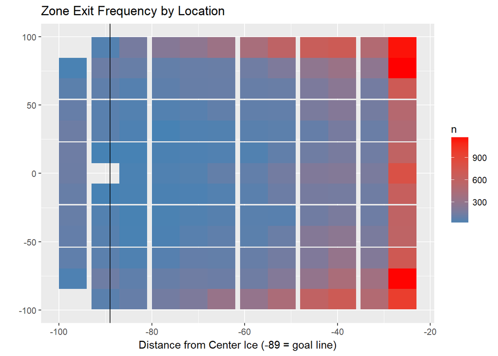

```r
ggplot(exit_success, aes(x = main_x, y = main_y)) +
  geom_tile(aes(fill = n)) +
  scale_fill_gradient(high = "red", low = "steelblue") +
  xlab("Distance from Center Ice (-89 = goal line)") +
  ylab("") +
  ggtitle("Zone Exit Frequency by Location") +
  geom_vline(xintercept=-89) #Add goal line
```

Interestingly, we can see that most zone exits begin far from the goal, particularly near the boards.